# Общее

**Отчёт посвящён продлениям и сравнению процента продлений в разных группах.**

- Отчёте будут рассмотрены самые разные факторы, которые могут влиять на продления.

Сначала попробуем посмотреть, как от месяца к месяцу менялась вероятность продления

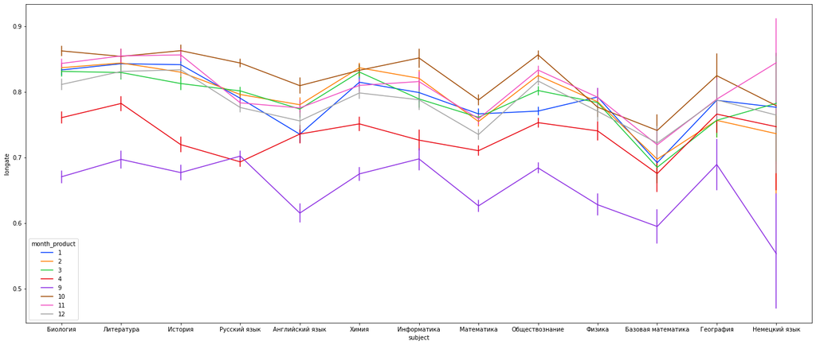

Любопытный график выше

```
Процент учеников перешедших из апреля в май - 73.34 %
Если посмотреть на продление в разные месяцы, то получается такая картина:
 month_product
1     80.26
2     81.44
3     80.76
4     73.31
9     68.18
10    84.14
11    81.50
12    79.74
Name: longate, dtype: float64
```

Процент учеников перешедших из апреля в май - 73.34 %

Процент учеников перешедших из апреля в предбанник не взяв мастер-группу - 9.49%

Если посмотреть на продление в разные месяцы, то получается такая картина:

Месяцы/продления

- Сентябрь. 68.18 %
- Октябрь. 84.14 %
- Ноябрь. 81.50 %
- Декабрь. 79.74 %
- Январь. 80.26 %
- Февраль. 81.44 %
- Март. 80.76 %
- Апрель. **73.31** %

Итак, можно считать, что наше предположение подтвердилось.

В лучший месяц процент продлений был **84.14% (Октябрь)**, а второй **81.50% (Ноябрь)**.

Если считать, что из апреля в май перешло **73.34%** - в мг + **9.49%** - сразу на предбанник, то можно считать, что **82.83%** перешли из апреля в май. Это нисколько не является заниженным показателем.

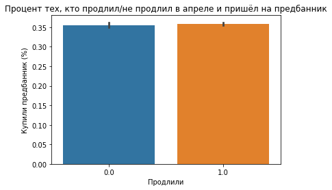

- Интересный момент, который я заметил попутно. Из ребят, которые продлили и не продлили в апреле, практически одинаковый процент пошли на предбанник.

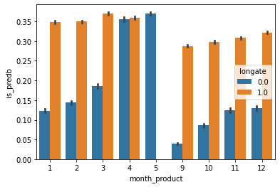

- Интересный график сверху. Начиная от сентября и заканчивая мартом у нас растёт процент тех, кто в итоге запишется на предбанник, причём как среди тех, кто продлевает месяц, так и среди тех, кто уходит.
- Однако, процент тех кто "Остается" и оказывается на предбаннике растёт медленно и скорее находится на одном уровне около 30%, в то время как среди уходящих, но пришедших на предбанник наблюдается значимый рост

# Влияние курсов

Одним из существенных факторов влияющих на вероятность продления может быть факт наличия у него курсов.

В начале поделим курсы на платные и бесплатные и будем говорить лишь о факте присутствия курса, а не о количестве.

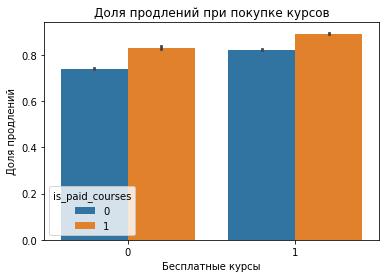

- График сверху демонстрирует, что среди тех кто использует бесплатные курсы - продлений больше, а так же среди тех кто использует бесплатные курсы совместно с платными - ещё больший процент продления.

Иначе говоря "вероятность продления" при покупке бесплатных курсов или платных курсов - одинакова.

**Посмотрим на то, влияет ли количество купленных/бесплатных курсов на продление**

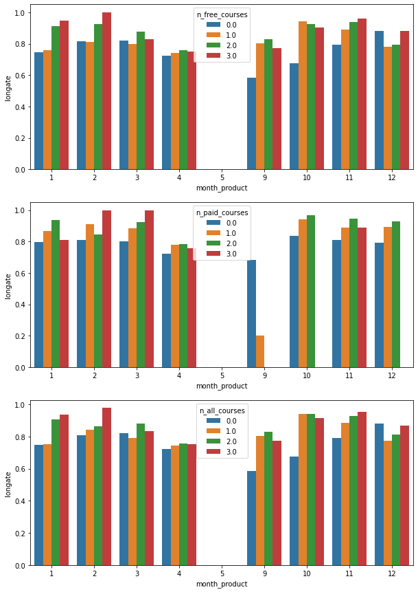

**Декабрь имеет подозрительную странность**

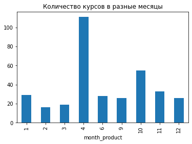

- Декабрь не отличался большим разнообразием курсов

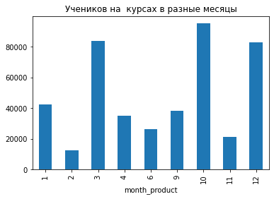

- А вот учеников было по настоящему много. Попробуем понять какой курс "испортил" статистику

|  | product_title | n_students | longate |
| --- | --- | --- | --- |
| 8 | Курс с психологами по саморазвитию \| Блок 2 | 79075 | 0.711364 |
| 6 | Курс по основам Обществознания с Равилем | 5604 | 0.674945 |
| 10 | Повышенный уровень домашнего задания для МГ де... | 2918 | 0.542147 |
| 16 | Школа PR, рекламы и маркетинга | 1642 | 0.836417 |
| 3 | Игра "Рулетка" по русскому языку ЕГЭ - Декабрь | 1525 | 0.935602 |
| 22 | Школа педагогики | 1361 | 0.841659 |
| 24 | Школа экономики | 1301 | 0.842764 |
| 14 | Углеводороды | 1190 | 0.735327 |
| 21 | Школа медицины | 1071 | 0.849232 |
| 20 | Школа лингвистики | 991 | 0.847710 |
| 25 | Школа юриспруденции | 972 | 0.848338 |
| 19 | Школа журналистики | 915 | 0.806538 |
| 15 | Школа IT | 799 | 0.824394 |
| 9 | Новогодний подарок: самые важные темы ОГЭ | 663 | 0.907320 |
| 17 | Школа архитектуры и дизайна | 511 | 0.854482 |
| 7 | Курс по основам биологии ОГЭ с Никитой | 496 | 0.592047 |

- Нормальный, или хороший уровень продления это 80%
- По таблице видно, что курс по психологии влияет на продления заметно больше остальных курсов
- Сложно объяснить, почему курс по психологии так повлиял. Может быть на этот курс пошли в основном те, кто в других обстоятельствах бы тоже ушёл?
- Попробуем посмотреть насколько этот курс популярный в сравнении с другими

|  | month_product | product_title | student_id |
| --- | --- | --- | --- |
| 458 | 12 | Курс с психологами по саморазвитию \| Блок 2 | 79075 |
| 59 | 3 | Курс с психологами по саморазвитию \| Блок 3 | 63287 |
| 370 | 10 | Демо Пролог | 28720 |
| 58 | 3 | Курс по основам истории | 25530 |
| 4 | 1 | Курс по основам Русского языка | 24715 |
| 223 | 5 | Предбанник по русскому языку - ЕГЭ | 15409 |
| 372 | 10 | Задание 12 | 13349 |
| 345 | 9 | Курс по основам математики с Артуром ЕГЭ | 11670 |
| 218 | 5 | Предбанник по обществознанию - ЕГЭ | 11646 |
| 368 | 10 | Геометрия с нуля | 10936 |

- Итак, это действительно самый большой курс.
- Можно предположить, что на него записывались ученики, которые не имели планов остаться. Не думаю, что здесь была какая-то каузация.
- Есть возможность сравнить Два курса с психологом: в марте и декабре.

```
Количество учеников на курсе - Курс с психологами по саморазвитию | Блок 2: 79075
Количество учеников на курсе - Курс с психологами по саморазвитию | Блок 3: 63287
Количество учеников которые учились и там и там: 55041
```

- У нас есть около 55 тысяч учеников, которые были на курсе и в декабре, и в марте. Посмотрим как сложилась их судьба в первый месяц.

|  | month_product | n_student |
| --- | --- | --- |
| 3 | 12 | 33828 |
| 2 | 3 | 52531 |
| 1 | 2 | 48520 |
| 0 | 1 | 36542 |

- Среди тех кто был на курсе по психологии в декабре, далеко не все имели какую-то мастер-группу, а в январе и далее они её уже приобрели.
- Это наталкивает на мысль, что среди посещавших курс по психологии в декабре было мало тех, кто имел мастер группу

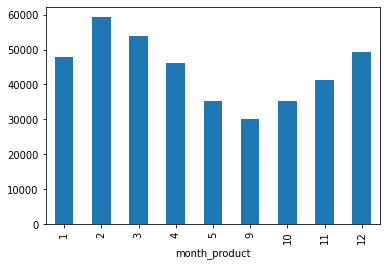

- Интересный эффект. По видимому, курс по психологии сыграл какой-то отложенный эффект. Доля учеников, которые учились на курсе и обзавелись мастер-группой увеличивалась с декабря по февраль и даже в марте была выше чем в декабре.
- Это не совсем ответ на вопрос, почему в декабре были низкие продления, но во-первых это точно связано с тем, что этот курс был крайне популярен, а во вторых, что в этом курсе училось много учеников, которые не имели мастер-группы

# Зависимость продления от количества Мг

- Проследим, влияет ли на "вероятность" продления то, что ученик взял более одного курса
- Cмотрим лишь на тех, кто взял не более 5 МГ

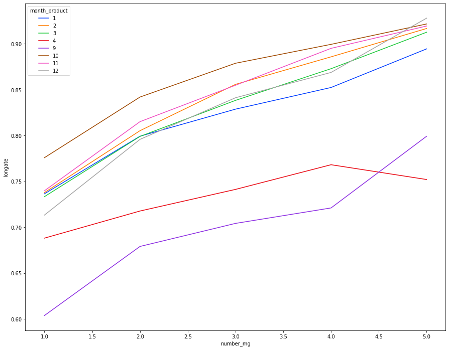

- Хорошо заметна тенденция на продление с увеличенем количества взятых курсов.
- Только в апреле те кто имел 5 МГ продлевали хуже чем те, кто имел 4 МГ. Но с аномалией апреля мы уже знакомы.

**Количество домашек на один предмет в зависимости от количества взятых предметов**

- Итак, ученики взявшие большее количество МГ лучше продлевают. Но делают ли они лучше ДЗ?

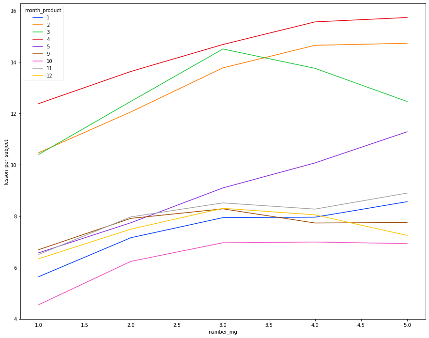

- Любопытно как у нас выделяются 3 "старательных" месяца: Февраль, март и апрель, и все остальные
- Удивительно, что от количества курсов, среднее количество домашек на курс не имеет тенденции уменьшаться
- Надо понимать, что во втором графике отмечались только те ученики, которые делали хотя бы одну домашку в мг

**Гипотеза/Вывод**

- Если у ученика большее количество МГ, то он будет более склонен продлевать.
- При этом дети, согласившиеся купить большее количество курсов как правило отсносятся к ним в равной степени серьёзно.

Что можно сделать с этой информацией?

- Мы можем подсчитать скидку, которую можно сделать за покупку 2-3-4 курса, с учётом потенцильной вероятности продления
- По сути это зелёный свет для проведения эксперимента с бесплатным 4-м курсом

# Продления и количество выполненных ДЗ в МГ

Посмотрим сначала на распределение количества выполненных домашек в месяц. По классам

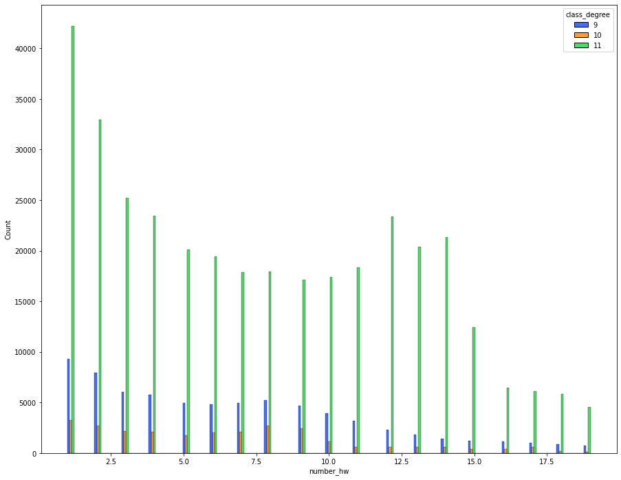

- На графике выше я отрезал нули. То есть здесь нет количества учеников которые бы сделали 0 домашек
- Как видно, нельзя сравнивать учеников из разных классов по количеству выполненных домашек
- Для простоты дальше буду работать только с ЕГЭ
- Посмотрим, что происходит с "Нулями"

| subject | n_students | longate | normal_students | longate_normal | zero_hw_percent | longate_diff |
| --- | --- | --- | --- | --- | --- | --- |
| Немецкий язык | 346 | 0.661850 | 441 | 0.802721 | 0.44 | 0.141 |
| География | 1297 | 0.692367 | 2623 | 0.894014 | 0.33 | 0.202 |
| Базовая математика | 4908 | 0.606561 | 5946 | 0.757989 | 0.45 | 0.151 |
| Физика | 7892 | 0.659529 | 14663 | 0.834413 | 0.35 | 0.175 |
| Информатика | 8107 | 0.673739 | 14478 | 0.863172 | 0.36 | 0.189 |
| Английский язык | 10464 | 0.665042 | 18475 | 0.829716 | 0.36 | 0.165 |
| Литература | 11422 | 0.702504 | 28758 | 0.896794 | 0.28 | 0.194 |
| История | 15732 | 0.685736 | 30736 | 0.893935 | 0.34 | 0.208 |
| Биология | 27011 | 0.732146 | 37464 | 0.882447 | 0.42 | 0.150 |
| Химия | 27853 | 0.777223 | 27233 | 0.862887 | 0.51 | 0.086 |
| Математика | 29616 | 0.650189 | 53536 | 0.836951 | 0.36 | 0.187 |
| Обществознание | 31456 | 0.674784 | 67362 | 0.869318 | 0.32 | 0.195 |
| Русский язык | 36279 | 0.697235 | 85192 | 0.843401 | 0.30 | 0.146 |

**n_students** - количество учеников не решавших домашку

**longate** - вероятность продления учеников не решавших домашку

**normal_students** - количество учеников решавших домашку

**longate_normal** - вероятность продления учениками решавших домашку

**zero_hw_percent** - доля учеников не решавших домашку

**longate_diff** - разница между longate и longate_normal

- В целом заметно, что невыполненные домашки снижают вероятность продления
- При этом, очевидно, что это снижение ощутимо, но не драматично - примерно на 17%

**Построим некоторые зависимости на основе предыдущей таблицы**

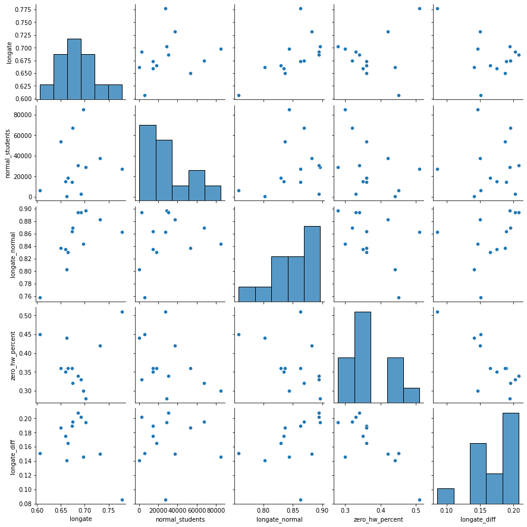

Интересные зависимости:

- longate vs longate_normal
- longate_normal vs longate_diff
- zero_hw_percent vs longate_diff
- zero_hw_percent vs longate

Попробуем их построить и детально изучить

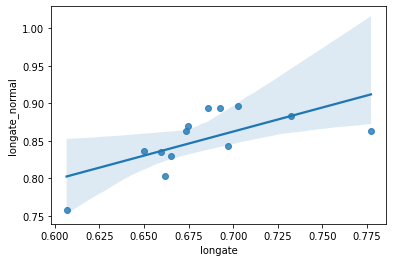

На графике видно, что продление учеников которые не решали ДЗ и продление всех учеников связаны линейно. Однако на это фоне выделяются Химия и базовая математика.

- У химии очень высокий уровень продлений среди учеников, которые не решали ДЗ. Вероятно это связано с тем, что у нас нет информации о домашках Лии, в то время как есть информация о её покупках. Косвенно этот факт подтверждает то, что у Биологии следующий после Химии показатель longate
- Базовая математика - самый плохо продляемый предмет из всех.

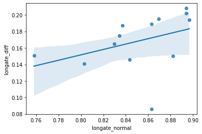

На графике заметна точка, выделяющиеся на фоне остальных. И это вновь Химия. В остальном выводе сделанные по предыдущему графику подтверждаются.

Добавляется ещё одна деталь:

- Разница между продлениями учеников которые не делали домашки и всеми учениками растёт, по мере роста продлений всех учеников.

Иначе говоря, чем больше продлевают ученики вообще, тем больше разница между учениками делающими домашку и теми, кто не делает.

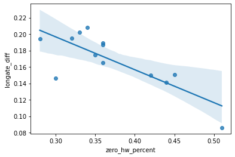

Доля учеников не делающих домашки линейна связана с разницей между продлениями нормальных учеников и халтурщиков.

Результат немного парадоксальный.

Получается, что чем меньше учеников у вас не делают домашку, тем больше разница в вероятности продления, в сравнении с учениками, которые делают домашку.

На языке халтурщиков и нормальных учеников это будет звучать так: чем меньше у вас халтурщиков, тем большая разница в вероятности продления между халтурщиками и нормальными учениками.

Отличается здесь от всех - Русский язык. У него 30% учеников не выполняют ДЗ, при этом разница между нормальными и халтурщиками на уровне 0.15. Такой уровень обычно достигается теми, кто имеет долю халтурщиков около 0.4-0.45

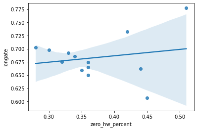

На графике мы можем видеть, как связана доля халтурщиков и вероятность их продления

График поделён по сути на две части:

- Область с **низким** значением zero_hw_percent
- Область с **высоким** значением zero_hw_percent

Внутри **низкой** области наблюдается слабая тенденция к увеличению вероятности продления, с уменьшемнием доли халтурщиков

Внутри **высокой** области находятся уже знакомые нам Биология, Химия и Базовая математика. А так же Немецкий язык.

Немецкий - это предмет, с наименьшим количеством учеников и который больше остальных подвержен случайностям в данных.

# Оторожные Итоги

- Каждый из предложенных параметров влияет на вероятность продления
- Трудно оценить какой влияет сильнее, поскольку очевидно, что многие факторы переплетены друг с другом
- Достоверно можно говорить о том, что факт присутсвия курсов(вне зависимости платные они или нет) хорошо сказывается на дальнейшем удержании ученика
- Как оказалось, курсы сильнее влияют на продления в первые месяцы: сентябрь, октябрь, ноябрь. Далее их влияние падает.
- Большее количество МГ делает приводит к улучшению продления, однако здесь не стоит забывать, что больше МГ берут как раз таки зубрилы
- Хорошо видно, что с увеличением количества МГ, интенсивность решения ДЗ по ним не падает
- Однако в то же время существенная доля учеников (~30%) не решают домашку вовсе, при этом в ~60-70% случаев продлевают обучение
- Ученики решвившие домашку хотя бы один раз продлевают на 15-20% лучше
- Уменьшение доли халтурщиков, может приводить к двойному эффекту: халтурщики сами начинают продлевать немного лучше, при этом остальные ученики продлевают ещё лучше обычного.